# Revision for the exam

Ariane IRADUKUNDA

2025-10-18

## (1) Identify and list data quality issues with this dataset

```r
# Loading required libraries
library(readxl)
library(dplyr)
# Loading the dataset
file_path <- "C:/Users/airadukunda/Downloads/DataFile.xls"
df <- read_excel(file_path)

# 1. Check for missing values in each column
missing_values <- colSums(is.na(df))
print("Missing Values per Column:")
```

```
## [1] "Missing Values per Column:"
```

```r
print(missing_values)
```

```
##                 Case No.                   Sector                 District
##                        0                        0                        0
##                 Province                      Sex                      Age
##                        0                       13                       22
##            Date of onset        Date of admission        Date of discharge
##                       19                       43                      833
##                    Death Signs and symptoms (D/V)     Specimen taken (Y/N)
##                     1973                      130                      752
##               Lab_Result                 Comments                Txt Given
##                     1526                     1447                     1534
##                  Outcome           Place of Death                   Status
##                     1534                     2050                     1534
##          Water treatment             Water source            In/Outpatient
##                     1927                     1534                     1534
```

```r
# 2. Unique values in 'Sex' and 'Outcome'
unique_sex <- unique(na.omit(df$Sex))
unique_outcome <- unique(na.omit(df$Outcome))
cat("\nUnique values in 'Sex':\n")
```

```
##
## Unique values in 'Sex':
```

```r
print(unique_sex)
```

```
## [1] "F"      "M"      "m"      "f"      "male"   "Male"   "Female" "3y11m"
```

```r
cat("\nUnique values in 'Outcome':\n")
```

```
##
## Unique values in 'Outcome':
```

```r
print(unique_outcome)
```

```
## [1] "Transferred" "Died"        "Discharged"  "Admitted"    "admitted"
## [6] "died"
```

```r
# 3. Sample of problematic Age entries
set.seed(123)
age_samples <- sample(na.omit(df$Age), 10)
cat("\nSample Age entries:\n")
```

```
##
## Sample Age entries:
```

```r
print(age_samples)
```

```
##  [1] "11"    "3"     "42"    "69"    "35"    "2yrs"  "44yrs" "45yrs" "37yrs"
## [10] "4yrs"
```

```r
# 4. Sample of Date of Onset entries
date_samples <- sample(na.omit(df$`Date of onset`), 10)
cat("\nSample Date of Onset entries:\n")
```

```
##
## Sample Date of Onset entries:
```

```r
print(date_samples)
```

```
##  [1] "39756"    "28/11/08" "39758"    "39790"    "39769"    "18/11/08"
##  [7] "4512//08" "39784"    "11/26/08" "21/11/08"
```

```r
# 5. Check for duplicate case numbers
duplicate_cases <- sum(duplicated(df$`Case No.`))
cat("\nNumber of duplicate case numbers:", duplicate_cases, "\n")
```

```
##
## Number of duplicate case numbers: 1429
```

```r
## The codes above describes the following:
#Reads your Excel file using readxl.
#Counts missing values for each column.
#Lists unique values in Sex and Outcome to spot inconsistencies.
#Shows samples of Age and Date of Onset for format issues.
#Counts duplicate case numbers.
```

```r
## (2) Harmonize the codification of the variable “Sex”

# Inspecting unique values before cleaning
cat("Before harmonization:\n")
```

```
## Before harmonization:
```

```r
print(unique(df$Sex))
```

```
## [1] "F"      "M"      "m"      "f"      "male"   "Male"   "Female" NA
## [9] "3y11m"
```

```r
# Harmonize 'Sex' variable
df <- df %>%
  mutate(Sex = tolower(trimws(Sex)),        # Convert to lowercase and remove spaces
         Sex = case_when(
           Sex %in% c("m", "male") ~ "Male",
           Sex %in% c("f", "female") ~ "Female",
           TRUE ~ NA_character_           # Assign NA for invalid or unknown entries
         ))

# Inspect unique values after cleaning
cat("\nAfter harmonization:\n")
```

```
##
## After harmonization:
```

```r
print(unique(df$Sex))
```

```
## [1] "Female" "Male"   NA
```

```r
## (3) Recode the variable “Age” into “AgeGroup” using the following age classes:
# a. Less than 5 years
# b. 5-14 years
# c. 15-24 years
# d. 25-49 years
# e. 50 years and above


# Converting Age to numeric where possible
# Removing text like 'yrs', 'yr', 'years', and handle months
df <- df %>%
  mutate(Age_clean = as.numeric(gsub("[^0-9]", "", Age)))  # Extract digits only

# Creating Age Group variable
df <- df %>%
  mutate(AgeGroup = case_when(
    is.na(Age_clean) ~ "Unknown",
    Age_clean < 5 ~ "Less than 5 years",
    Age_clean >= 5 & Age_clean <= 14 ~ "5-14 years",
    Age_clean >= 15 & Age_clean <= 24 ~ "15-24 years",
    Age_clean >= 25 & Age_clean <= 49 ~ "25-49 years",
    Age_clean >= 50 ~ "50 years and above"
  ))

# Checking the distribution of Age Group
table(df$AgeGroup)
```

```
##
##        15-24 years        25-49 years         5-14 years 50 years and above
##                504                751                300                309
##  Less than 5 years            Unknown
##                167                 35
```

```r
## These codes helped to Clean the Age column by removing text and converting to numeric.
## Creates a new column Age Group with the five specified categories.
## Displays the frequency of each age group using table().
```

[figure not shown]

```r
## (4) Perform the statistical analyses required and produce outputs (graphs and tables)

library(ggplot2)


#Data Cleaning
# Harmonize Sex
df <- df %>%
  mutate(Sex = tolower(trimws(Sex)),
         Sex = case_when(
           Sex %in% c("m", "male") ~ "Male",
           Sex %in% c("f", "female") ~ "Female",
           TRUE ~ NA_character_
         ))

# Clean Age and create Age Group
df <- df %>%
  mutate(Age_clean = as.numeric(gsub("[^0-9]", "", Age)),
         AgeGroup = case_when(
           is.na(Age_clean) ~ "Unknown",
           Age_clean < 5 ~ "Less than 5 years",
           Age_clean >= 5 & Age_clean <= 14 ~ "5-14 years",
           Age_clean >= 15 & Age_clean <= 24 ~ "15-24 years",
           Age_clean >= 25 & Age_clean <= 49 ~ "25-49 years",
           Age_clean >= 50 ~ "50 years and above"
         ))

# Key Indicators

# Total cases
total_cases <- nrow(df)

# Geographical distribution
geo_dist <- df %>% count(Province)

# Deaths and Case Fatality Rate
deaths <- sum(grepl("died", tolower(df$Outcome), ignore.case = TRUE), na.rm = TRUE)
cfr <- (deaths / total_cases) * 100

# Age group distribution
age_dist <- df %>% count(AgeGroup)

# Gender distribution
gender_dist <- df %>% count(Sex)

# Outcome distribution
outcome_dist <- df %>% count(Outcome)

# Recovery rate
recovered <- sum(grepl("discharged|alive|improved", tolower(df$Outcome), ignore.case = TRUE), na.rm = TRUE)
recovery_rate <- (recovered / total_cases) * 100


# Visualizations

# Epidemic Curve

df$`Date of onset` <- as.Date(df$`Date of onset`, format = "%d/%m/%Y")
epi_curve <- df %>%
  filter(!is.na(`Date of onset`)) %>%
  count(`Date of onset`)

ggplot(epi_curve, aes(x = `Date of onset`, y = n)) +
  geom_line(color = "blue") +
  labs(title = "Epidemic Curve", x = "Date of Onset", y = "Number of Cases") +
  theme_minimal()
```

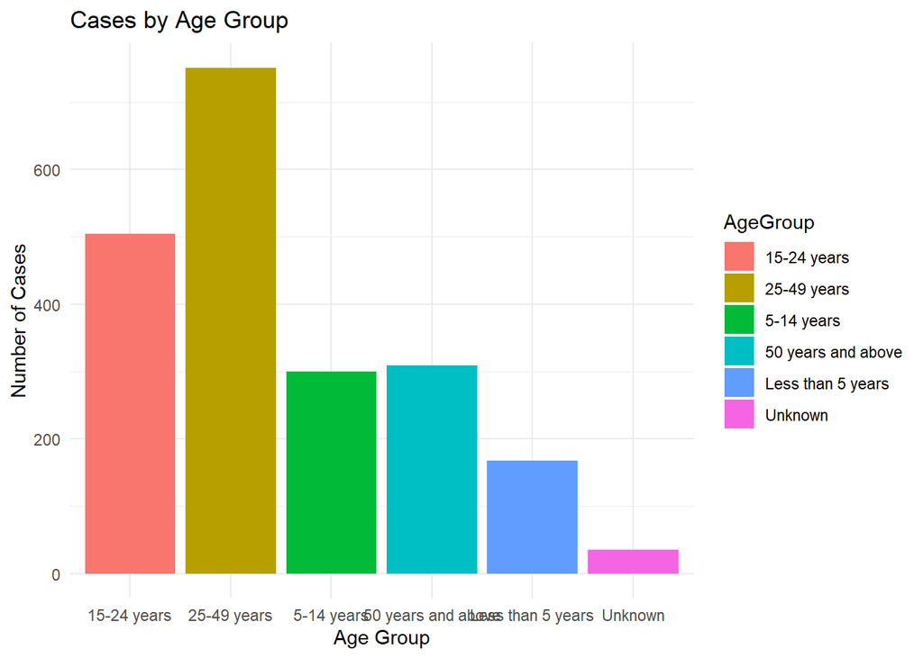

```r
# Age Group Bar Chart

ggplot(age_dist, aes(x = AgeGroup, y = n, fill = AgeGroup)) +
  geom_bar(stat = "identity") +
  labs(title = "Cases by Age Group", x = "Age Group", y = "Number of Cases") +
  theme_minimal()
```

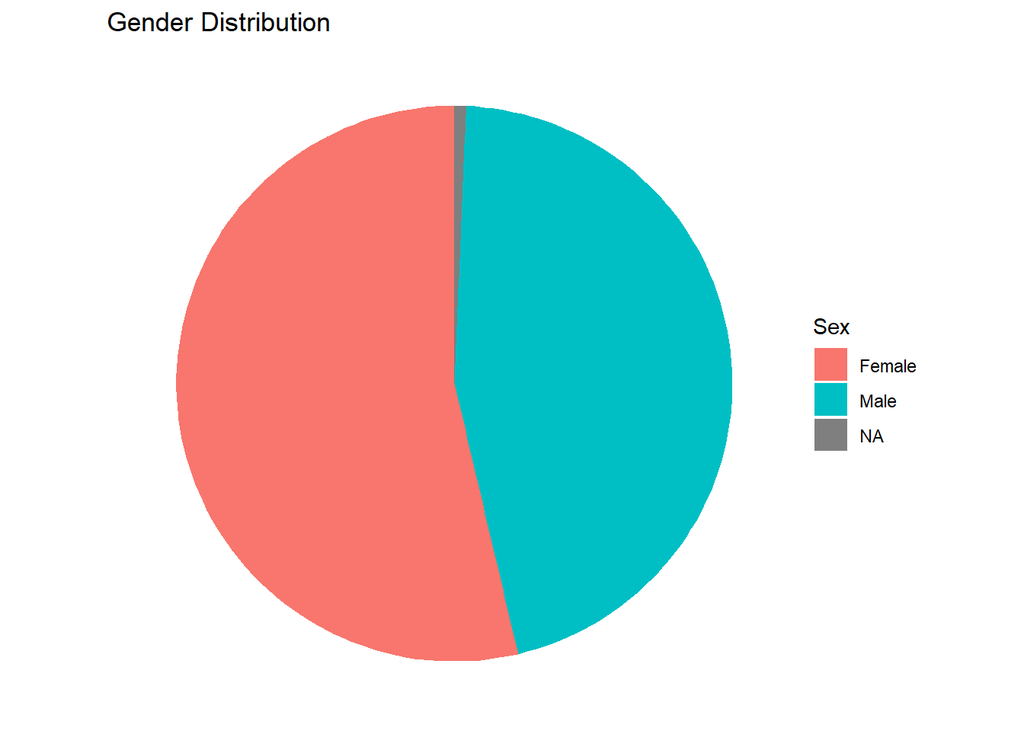

```r
# Gender Distribution Pie Chart

gender_dist$prop <- gender_dist$n / sum(gender_dist$n)
ggplot(gender_dist, aes(x = "", y = prop, fill = Sex)) +
  geom_bar(stat = "identity", width = 1) +
  coord_polar("y") +
  labs(title = "Gender Distribution") +
  theme_void()
```

```r
# Print Summary Tables

cat("\nTotal Cases:", total_cases)
```

```
##
## Total Cases: 2066
```

```r
cat("\nDeaths:", deaths)
```

```
##
## Deaths: 16
```

```r
cat("\nCase Fatality Rate (%):", round(cfr, 2))
```

```
##
## Case Fatality Rate (%): 0.77
```

```r
cat("\nRecovery Rate (%):", round(recovery_rate, 2), "\n")
```

```
##
## Recovery Rate (%): 20.67
```

```r
print(geo_dist)
```

```
## # A tibble: 2 × 2
##   Province       n
##   <chr>      <int>
## 1 Province 1   532
## 2 Province 2  1534
```

```r
print(age_dist)
```

```
## # A tibble: 6 × 2
##   AgeGroup               n
##   <chr>              <int>
## 1 15-24 years          504
## 2 25-49 years          751
## 3 5-14 years           300
## 4 50 years and above   309
## 5 Less than 5 years    167
## 6 Unknown               35
```

```r
print(gender_dist)
```

```
## # A tibble: 3 × 3
##   Sex        n    prop
##   <chr>  <int>   <dbl>
## 1 Female  1109 0.537
## 2 Male     943 0.456
## 3 <NA>      14 0.00678
```

```r
print(outcome_dist)
```

```
## # A tibble: 7 × 2
##   Outcome         n
##   <chr>       <int>
## 1 Admitted       57
## 2 Died           15
## 3 Discharged    427
## 4 Transferred     8
## 5 admitted       24
## 6 died            1
## 7 <NA>         1534
```

#### These codes Loaded and cleaned data:

#### Converted Age to numeric and creates AgeGroup.

#### Calculated key indicators:Total cases, deaths, CFR, recovery rate , Distributions by province, age group, gender, and outcome.

#### Generated visualizations:

#### Epidemic curve (line chart).

#### Age group distribution (bar chart).

#### Gender distribution (pie chart).

#### Outputs summary tables for briefing.

## (5) Produce the necessary figures that allows visualization of the outbreak situation

[figure not shown]

```r
## 1. Epidemic Curve
# Convert Date of onset to Date format
df$`Date of onset` <- as.Date(df$`Date of onset`, format = "%d/%m/%Y")

# Aggregate cases by date
epi_curve <- df %>%
  filter(!is.na(`Date of onset`)) %>%
  group_by(`Date of onset`) %>%
  summarise(Cases = n())

# Plot epidemic curve
ggplot(epi_curve, aes(x = `Date of onset`, y = Cases)) +
  geom_line(color = "blue", size = 1) +
  labs(title = "Epidemic Curve", x = "Date of Onset", y = "Number of Cases") +
  theme_minimal()
```

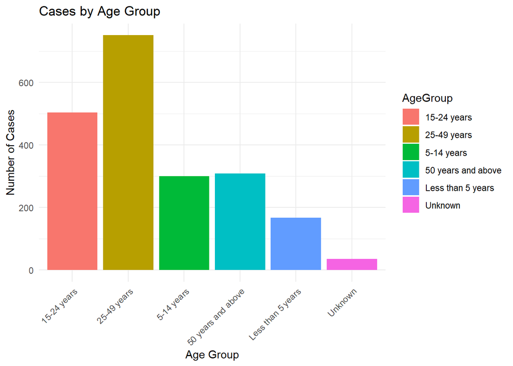

```r
## 2. Cases by Age Group

# Assuming AgeGroup was created in previous steps
age_dist <- df %>%
  group_by(AgeGroup) %>%
  summarise(Cases = n())

ggplot(age_dist, aes(x = AgeGroup, y = Cases, fill = AgeGroup)) +
  geom_bar(stat = "identity") +
  labs(title = "Cases by Age Group", x = "Age Group", y = "Number of Cases") +
  theme_minimal() +
  theme(axis.text.x = element_text(angle = 45, hjust = 1))
```

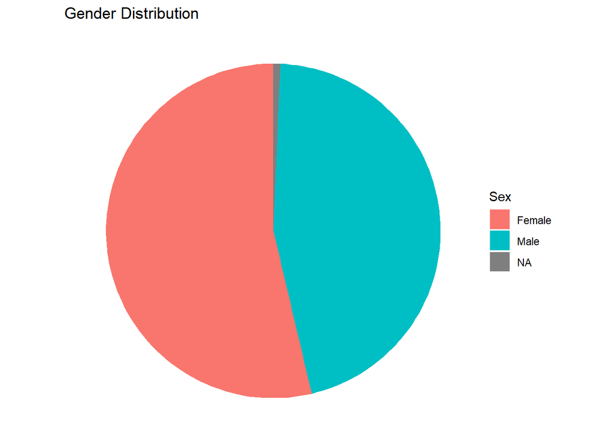

```r
## 3. Gender Distribution (Pie Chart)

gender_dist <- df %>%
  group_by(Sex) %>%
  summarise(Cases = n())

ggplot(gender_dist, aes(x = "", y = Cases, fill = Sex)) +
  geom_bar(stat = "identity", width = 1) +
  coord_polar("y") +
  labs(title = "Gender Distribution") +
  theme_void()
```

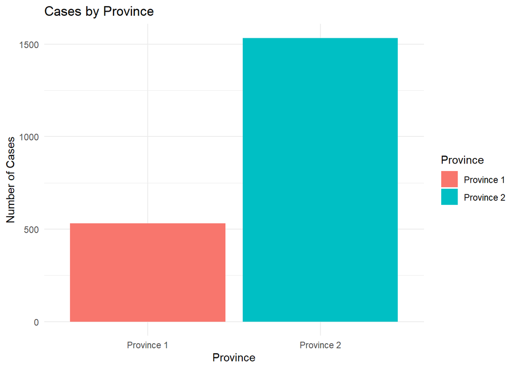

```r
## 4. Geographical Distribution by Province

geo_dist <- df %>%
  group_by(Province) %>%
  summarise(Cases = n())

ggplot(geo_dist, aes(x = Province, y = Cases, fill = Province)) +
  geom_bar(stat = "identity") +
  labs(title = "Cases by Province", x = "Province", y = "Number of Cases") +
  theme_minimal()
```

```r
## What these plots show
## Epidemic Curve: Trend of cases over time.
## Age Group Bar Chart: Most and least affected age groups.
## Gender Pie Chart: Gender distribution of cases.
## Province Bar Chart: Geographical distribution of cases.
```

```r
# Cleaning relevant variables
# Harmonize water treatment and source
df <- df %>%
  mutate(WaterTreatment = tolower(trimws(`Water treatment`)),
         WaterSource = tolower(trimws(`Water source`)),
         OutcomeClean = tolower(trimws(Outcome)))

# Create binary outcome for death
df <- df %>%
  mutate(Death = ifelse(grepl("died", OutcomeClean), 1, 0))

# Summarizing risk factors

# Water treatment status
water_treatment_summary <- df %>%
  group_by(WaterTreatment) %>%
  summarise(Cases = n(),
            Deaths = sum(Death),
            CFR = round((Deaths / Cases) * 100, 2))

water_source_summary <- df %>%
  group_by(WaterSource) %>%
  summarise(Cases = n(),
            Deaths = sum(Death),
            CFR = round((Deaths / Cases) * 100, 2))

# Inpatient vs Outpatient
inout_summary <- df %>%
  group_by(`In/Outpatient`) %>%
  summarise(Cases = n(),
            Deaths = sum(Death),
            CFR = round((Deaths / Cases) * 100, 2))

## Print summaries
cat("\nRisk Factor: Water Treatment\n")
```

```
##
## Risk Factor: Water Treatment
```

```r
print(water_treatment_summary)
```

```
## # A tibble: 4 × 4
##   WaterTreatment Cases Deaths   CFR
##   <chr>          <int>  <dbl> <dbl>
## 1 boil               1      1 100
## 2 boiling           14      0   0
## 3 none             124     15  12.1
## 4 <NA>            1927      0   0
```

```r
cat("\nRisk Factor: Water Source\n")
```

```
##
## Risk Factor: Water Source
```

```r
print(water_source_summary)
```

```
## # A tibble: 3 × 4
##   WaterSource Cases Deaths   CFR
##   <chr>       <int>  <dbl> <dbl>
## 1 improved      408      0   0
## 2 unimproved    124     16  12.9
## 3 <NA>         1534      0   0
```

```r
cat("\nRisk Factor: Inpatient vs Outpatient\n")
```

```
##
## Risk Factor: Inpatient vs Outpatient
```

```r
print(inout_summary)
```

```
## # A tibble: 9 × 4
##   `In/Outpatient` Cases Deaths    CFR
##   <chr>           <int>  <dbl>  <dbl>
## 1 Comm                2      2 100
## 2 IN                  2      0   0
## 3 In                 19      2  10.5
## 4 Inp                 6      1  16.7
## 5 Out                47      3   6.38
## 6 in                 76      3   3.95
## 7 never               1      1 100
## 8 out               379      4   1.06
## 9 <NA>             1534      0   0
```

```r
## this code helps Cleaning and standardizing Water treatment, Water source, and Outcome.
## Creates a binary variable for death.
## Calculates:Cases, Deaths, and Case Fatality Rate (CFR) for each risk factor category.
## Performs a Chi-square test to check if water treatment is significantly associated with death.
## Expected Insights: Lack of water treatment (e.g., “none”) likely shows higher CFR.
## Unsafe water sources (e.g., “river”, “unprotected well”) may correlate with more cases.
## Outpatients might have higher mortality if they did not receive timely care
```

[output not shown]

[output not shown]

### (7) Looking at the data you received, what recommendations would you provide to strengthen surveillance and outbreak response? Clearly and concisely discuss your thoughts.

#### 1.Improve Data Quality and Standardization

Standardize coding for key variables (Sex, Age, Outcome) across all reporting sites. Implement real time data validation during entry to reduce missing values and duplicates. Use digital tools (mobile apps or DHIS2 modules) for consistent reporting formats.

#### 2.Enhance Surveillance Systems

Establish rapid reporting channels from health facilities and community health workers. Integrate laboratory confirmation into the line list to improve case classification. Monitor water source and treatment data systematically to identify high-risk areas early.

#### 3. Strengthen Outbreak Response

Deploy rapid response teams to provinces with the highest case burden. Ensure adequate stock of ORS, IV fluids, and antibiotics in affected districts. Set up cholera treatment centers closer to communities to reduce deaths at home or in transit.

#### 4. Community Engagement and Risk Communication

Intensify public education campaigns on safe water practices (chlorination, boiling). Promote early care-seeking behavior for diarrhea and dehydration symptoms. Work with local leaders to address cultural barriers to timely treatment.

#### 5. Environmental and Preventive Measures

Improve access to safe water and sanitation facilities in high-risk sectors. Conduct regular water quality monitoring and chlorination in communal sources. Implement targeted hygiene interventions in schools and markets.